# Non-parametric survival methods in R: comparing groups

Shannon Pileggi

February 9, 2018

# Getting started

For illustration, we’ll use the `ovarian` data set located in the `survival` library. Recall that this data compares two treatments for ovarian cancer.

- `futime` = time to death
- `fustat` = censoring status (1 = complete, 0 = right censored)
- `rx` = treatment group (1/2)

To access the data set, execute the code below.

```r
# ovarian data set is in the survival library
library(survival)
data(ovarian)
```

Next, create your `survfit` model. In previous models, we used the syntax `~ 1` to indicate an intercept only model (not stratified). Now, we’ll use the syntax `~ group_var` to indicate to compute Kaplan-Meier curves separately for each group. In this case, `rx` defines our groups of interest.

```r
KM_obj <- survfit(Surv(futime, fustat) ~ rx, data = ovarian)
```

**Note:** If your `group_var` variable is coded numerically (as in 1/2, etc.) you need to explicitly tell R to treat this as a categorical rather than quantitative variable. You do this by wrapping the `group_var` variable in the `as.factor` function. A generic expression for this would look like:

```r
KM_obj <- survfit(Surv(time, censor) ~ as.factor(group_var), data = my_data)
```

# Obtaining estimates

Obtain the Kaplan-Meier survival estimates by group (`rx` in this case) by using the `summary` function:

```r
summary(KM_obj)
```

```
## Call: survfit(formula = Surv(futime, fustat) ~ rx, data = ovarian)
##
##                 rx=1
##  time n.risk n.event survival std.err lower 95% CI upper 95% CI
##    59     13       1    0.923  0.0739        0.789        1.000
##   115     12       1    0.846  0.1001        0.671        1.000
##   156     11       1    0.769  0.1169        0.571        1.000
##   268     10       1    0.692  0.1280        0.482        0.995
##   329      9       1    0.615  0.1349        0.400        0.946
##   431      8       1    0.538  0.1383        0.326        0.891
##   638      5       1    0.431  0.1467        0.221        0.840
##
##                 rx=2
##  time n.risk n.event survival std.err lower 95% CI upper 95% CI
##   353     13       1    0.923  0.0739        0.789        1.000
##   365     12       1    0.846  0.1001        0.671        1.000
##   464      9       1    0.752  0.1256        0.542        1.000
##   475      8       1    0.658  0.1407        0.433        1.000
##   563      7       1    0.564  0.1488        0.336        0.946
```

You can also obtain esimates of the median survival time in each group simply by printing the Kaplan-Meier object.

```r
KM_obj
```

```
## Call: survfit(formula = Surv(futime, fustat) ~ rx, data = ovarian)
##
##       n events median 0.95LCL 0.95UCL
## rx=1 13      7    638     268      NA
## rx=2 13      5     NA     475      NA
```

# Plots

## base R

When plotting in base R, you need to specify a graphical element to differentiate the curves. You can do this by color (`col`) or line type (`lty`) as shown belown. In this case, we have two groups, so I specified two different line types. Similarly, the two graphical elements need to be defined in the legend as well.

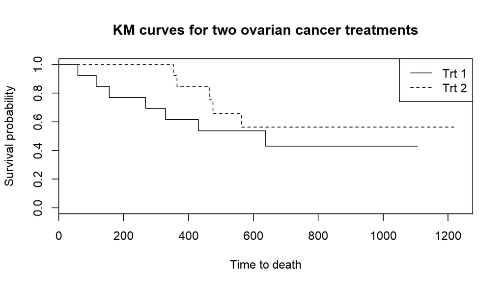

```r
plot(KM_obj,
     lty = 1:2,
     xlab = "Time to death",
     ylab = "Survival probability",
     main = "KM curves for two ovarian cancer treatments"
     )

legend("topright", c("Trt 1", "Trt 2"), lty = 1:2)
```

## ggsurvplot

To use a `gg` version of survival plotting, install the `survminer` package and use the `ggsurvplot` function. Note that this function has many options, including whether or not to plot confidence intervals (`conf.int`) or the risk table (`risk.table`).

```r
library(survminer)
```

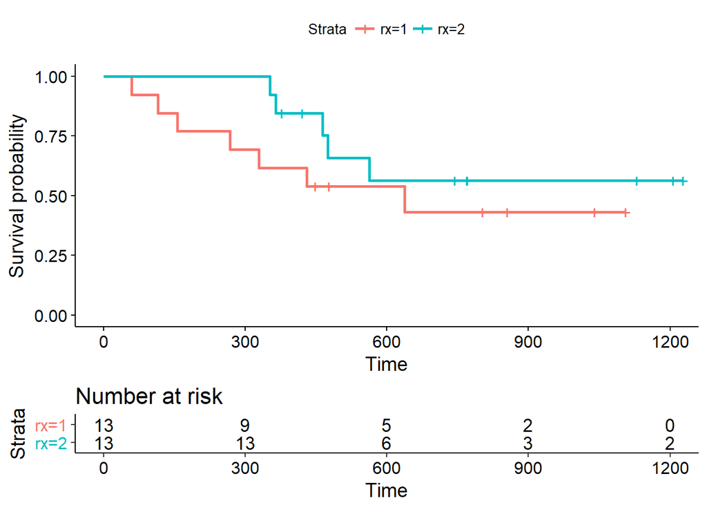

```r
ggsurvplot(KM_obj, data = ovarian, risk.table = TRUE)
```

# Log-rank test

Use the function `survdiff` on a survival object to perform the log-rank test.

```r
survdiff(Surv(futime, fustat) ~ rx, data = ovarian)
```

```
## Call:
## survdiff(formula = Surv(futime, fustat) ~ rx, data = ovarian)
##
##       N Observed Expected (O-E)^2/E (O-E)^2/V
## rx=1 13        7     5.23     0.596      1.06
## rx=2 13        5     6.77     0.461      1.06
##
##  Chisq= 1.1  on 1 degrees of freedom, p= 0.303
```

# Notes

- `R` does not provide the Wilcoxon test.
- Methods are the same if you have more than 2 groups.